# Risk Factor Analysis

## Outcome Variable

**Outcome Variable:** ever_co

## Predictor Variables

**Intervention Variable:** fage

**Adjustment Set:**

unadjusted

## Stratifying Variables

The analysis was stratified on these variable(s):

- agecat
- studyid
- country

## Data Summary

| agecat | studyid | country | fage | ever_co | n_cell | n | outcome_variable |
| --- | --- | --- | --- | --- | --- | --- | --- |
| 0-24 months | ki0047075b-MAL-ED | BANGLADESH | >=38 | 0 | 61 | 151 | ever_co |
| 0-24 months | ki0047075b-MAL-ED | BANGLADESH | >=38 | 1 | 8 | 151 | ever_co |
| 0-24 months | ki0047075b-MAL-ED | BANGLADESH | <32 | 0 | 22 | 151 | ever_co |
| 0-24 months | ki0047075b-MAL-ED | BANGLADESH | <32 | 1 | 8 | 151 | ever_co |
| 0-24 months | ki0047075b-MAL-ED | BANGLADESH | [32-38) | 0 | 45 | 151 | ever_co |
| 0-24 months | ki0047075b-MAL-ED | BANGLADESH | [32-38) | 1 | 7 | 151 | ever_co |
| 0-24 months | ki0047075b-MAL-ED | BRAZIL | >=38 | 0 | 30 | 79 | ever_co |
| 0-24 months | ki0047075b-MAL-ED | BRAZIL | >=38 | 1 | 0 | 79 | ever_co |
| 0-24 months | ki0047075b-MAL-ED | BRAZIL | <32 | 0 | 17 | 79 | ever_co |
| 0-24 months | ki0047075b-MAL-ED | BRAZIL | <32 | 1 | 1 | 79 | ever_co |
| 0-24 months | ki0047075b-MAL-ED | BRAZIL | [32-38) | 0 | 31 | 79 | ever_co |
| 0-24 months | ki0047075b-MAL-ED | BRAZIL | [32-38) | 1 | 0 | 79 | ever_co |
| 0-24 months | ki0047075b-MAL-ED | INDIA | >=38 | 0 | 33 | 161 | ever_co |
| 0-24 months | ki0047075b-MAL-ED | INDIA | >=38 | 1 | 3 | 161 | ever_co |
| 0-24 months | ki0047075b-MAL-ED | INDIA | <32 | 0 | 36 | 161 | ever_co |
| 0-24 months | ki0047075b-MAL-ED | INDIA | <32 | 1 | 17 | 161 | ever_co |
| 0-24 months | ki0047075b-MAL-ED | INDIA | [32-38) | 0 | 56 | 161 | ever_co |
| 0-24 months | ki0047075b-MAL-ED | INDIA | [32-38) | 1 | 16 | 161 | ever_co |
| 0-24 months | ki0047075b-MAL-ED | NEPAL | >=38 | 0 | 14 | 79 | ever_co |
| 0-24 months | ki0047075b-MAL-ED | NEPAL | >=38 | 1 | 3 | 79 | ever_co |
| 0-24 months | ki0047075b-MAL-ED | NEPAL | <32 | 0 | 13 | 79 | ever_co |
| 0-24 months | ki0047075b-MAL-ED | NEPAL | <32 | 1 | 2 | 79 | ever_co |
| 0-24 months | ki0047075b-MAL-ED | NEPAL | [32-38) | 0 | 43 | 79 | ever_co |
| 0-24 months | ki0047075b-MAL-ED | NEPAL | [32-38) | 1 | 4 | 79 | ever_co |
| 0-24 months | ki0047075b-MAL-ED | PERU | >=38 | 0 | 27 | 85 | ever_co |
| 0-24 months | ki0047075b-MAL-ED | PERU | >=38 | 1 | 0 | 85 | ever_co |
| 0-24 months | ki0047075b-MAL-ED | PERU | <32 | 0 | 27 | 85 | ever_co |
| 0-24 months | ki0047075b-MAL-ED | PERU | <32 | 1 | 2 | 85 | ever_co |
| 0-24 months | ki0047075b-MAL-ED | PERU | [32-38) | 0 | 27 | 85 | ever_co |
| 0-24 months | ki0047075b-MAL-ED | PERU | [32-38) | 1 | 2 | 85 | ever_co |

[output cut: 204 more lines]

The following strata were considered:

- agecat: 0-24 months, studyid: ki0047075b-MAL-ED, country: BANGLADESH
- agecat: 0-24 months, studyid: ki0047075b-MAL-ED, country: BRAZIL
- agecat: 0-24 months, studyid: ki0047075b-MAL-ED, country: INDIA
- agecat: 0-24 months, studyid: ki0047075b-MAL-ED, country: NEPAL
- agecat: 0-24 months, studyid: ki0047075b-MAL-ED, country: PERU
- agecat: 0-24 months, studyid: ki0047075b-MAL-ED, country: SOUTH AFRICA
- agecat: 0-24 months, studyid: ki0047075b-MAL-ED, country: TANZANIA, UNITED REPUBLIC OF
- agecat: 0-24 months, studyid: ki1000304b-SAS-CompFeed, country: INDIA
- agecat: 0-24 months, studyid: ki1000304b-SAS-FoodSuppl, country: INDIA
- agecat: 0-24 months, studyid: ki1119695-PROBIT, country: BELARUS
- agecat: 0-24 months, studyid: ki1135781-COHORTS, country: GUATEMALA
- agecat: 0-24 months, studyid: ki1135781-COHORTS, country: PHILIPPINES
- agecat: 0-24 months, studyid: ki1148112-LCNI-5, country: MALAWI
- agecat: 0-6 months, studyid: ki0047075b-MAL-ED, country: BANGLADESH
- agecat: 0-6 months, studyid: ki0047075b-MAL-ED, country: BRAZIL
- agecat: 0-6 months, studyid: ki0047075b-MAL-ED, country: INDIA
- agecat: 0-6 months, studyid: ki0047075b-MAL-ED, country: NEPAL
- agecat: 0-6 months, studyid: ki0047075b-MAL-ED, country: PERU
- agecat: 0-6 months, studyid: ki0047075b-MAL-ED, country: SOUTH AFRICA
- agecat: 0-6 months, studyid: ki0047075b-MAL-ED, country: TANZANIA, UNITED REPUBLIC OF
- agecat: 0-6 months, studyid: ki1000304b-SAS-CompFeed, country: INDIA
- agecat: 0-6 months, studyid: ki1000304b-SAS-FoodSuppl, country: INDIA
- agecat: 0-6 months, studyid: ki1119695-PROBIT, country: BELARUS
- agecat: 0-6 months, studyid: ki1135781-COHORTS, country: GUATEMALA
- agecat: 0-6 months, studyid: ki1135781-COHORTS, country: PHILIPPINES
- agecat: 0-6 months, studyid: ki1148112-LCNI-5, country: MALAWI
- agecat: 6-24 months, studyid: ki0047075b-MAL-ED, country: BANGLADESH
- agecat: 6-24 months, studyid: ki0047075b-MAL-ED, country: BRAZIL
- agecat: 6-24 months, studyid: ki0047075b-MAL-ED, country: INDIA
- agecat: 6-24 months, studyid: ki0047075b-MAL-ED, country: NEPAL
- agecat: 6-24 months, studyid: ki0047075b-MAL-ED, country: PERU
- agecat: 6-24 months, studyid: ki0047075b-MAL-ED, country: SOUTH AFRICA
- agecat: 6-24 months, studyid: ki0047075b-MAL-ED, country: TANZANIA, UNITED REPUBLIC OF
- agecat: 6-24 months, studyid: ki1000304b-SAS-CompFeed, country: INDIA
- agecat: 6-24 months, studyid: ki1000304b-SAS-FoodSuppl, country: INDIA
- agecat: 6-24 months, studyid: ki1119695-PROBIT, country: BELARUS
- agecat: 6-24 months, studyid: ki1135781-COHORTS, country: GUATEMALA
- agecat: 6-24 months, studyid: ki1135781-COHORTS, country: PHILIPPINES
- agecat: 6-24 months, studyid: ki1148112-LCNI-5, country: MALAWI

### Dropped Strata

Some strata were dropped due to rare outcomes:

- agecat: 0-24 months, studyid: ki0047075b-MAL-ED, country: BRAZIL
- agecat: 0-24 months, studyid: ki0047075b-MAL-ED, country: INDIA
- agecat: 0-24 months, studyid: ki0047075b-MAL-ED, country: NEPAL
- agecat: 0-24 months, studyid: ki0047075b-MAL-ED, country: PERU
- agecat: 0-24 months, studyid: ki0047075b-MAL-ED, country: SOUTH AFRICA
- agecat: 0-24 months, studyid: ki0047075b-MAL-ED, country: TANZANIA, UNITED REPUBLIC OF
- agecat: 0-24 months, studyid: ki1119695-PROBIT, country: BELARUS
- agecat: 0-24 months, studyid: ki1148112-LCNI-5, country: MALAWI
- agecat: 0-6 months, studyid: ki0047075b-MAL-ED, country: BANGLADESH
- agecat: 0-6 months, studyid: ki0047075b-MAL-ED, country: BRAZIL
- agecat: 0-6 months, studyid: ki0047075b-MAL-ED, country: INDIA
- agecat: 0-6 months, studyid: ki0047075b-MAL-ED, country: NEPAL
- agecat: 0-6 months, studyid: ki0047075b-MAL-ED, country: PERU
- agecat: 0-6 months, studyid: ki0047075b-MAL-ED, country: SOUTH AFRICA
- agecat: 0-6 months, studyid: ki0047075b-MAL-ED, country: TANZANIA, UNITED REPUBLIC OF
- agecat: 0-6 months, studyid: ki1000304b-SAS-FoodSuppl, country: INDIA
- agecat: 0-6 months, studyid: ki1119695-PROBIT, country: BELARUS
- agecat: 0-6 months, studyid: ki1135781-COHORTS, country: GUATEMALA
- agecat: 0-6 months, studyid: ki1148112-LCNI-5, country: MALAWI
- agecat: 6-24 months, studyid: ki0047075b-MAL-ED, country: BRAZIL
- agecat: 6-24 months, studyid: ki0047075b-MAL-ED, country: INDIA
- agecat: 6-24 months, studyid: ki0047075b-MAL-ED, country: NEPAL
- agecat: 6-24 months, studyid: ki0047075b-MAL-ED, country: PERU
- agecat: 6-24 months, studyid: ki0047075b-MAL-ED, country: SOUTH AFRICA
- agecat: 6-24 months, studyid: ki0047075b-MAL-ED, country: TANZANIA, UNITED REPUBLIC OF
- agecat: 6-24 months, studyid: ki1119695-PROBIT, country: BELARUS
- agecat: 6-24 months, studyid: ki1148112-LCNI-5, country: MALAWI

## Methods Detail

We’re interested in the causal parameters $E[Y_a]$ for all values of $a \in \mathcal{A}$. These parameters represent the mean outcome if, possibly contrary to fact, we intervened to set all units to have $A=a$. Under the randomization and positivity assumptions, these are identified by the statistical parameters $\psi_a=E_W[E_{Y|A,W}(Y|A=a,W)]$. In addition, we’re interested in the mean of $Y$, $E[Y]$ under no intervention (the observed mean). We will estimate these parameters by using SuperLearner to fit the relevant likelihood factors – $E_{Y|A,W}(Y|A=a,W)$ and $p(A=a|W)$, and then updating our likelihood fit using a joint TMLE.

For unadjusted analyses ($W=\{\}$), initial likelihoods were estimated using Lrnr_glm to estimate the simple $E(Y|A)$ and Lrnr_mean to estimate $p(A)$. For adjusted analyses, a small library containing Lrnr_glmnet, Lrnr_xgboost, and Lrnr_mean was used.

Having estimated these parameters, we will then use the delta method to estimate relative risks and attributable risks relative to a prespecified baseline level of $A$.

# Results Detail

## Results Plots

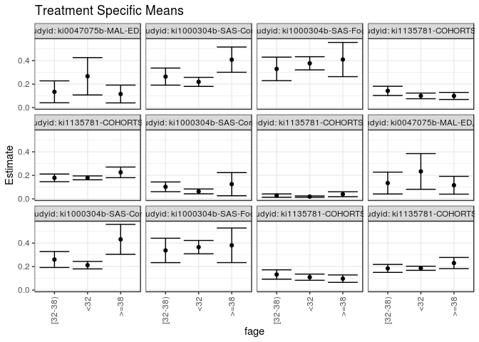

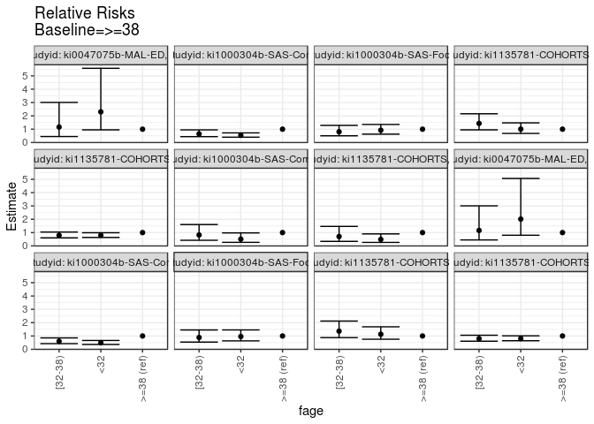

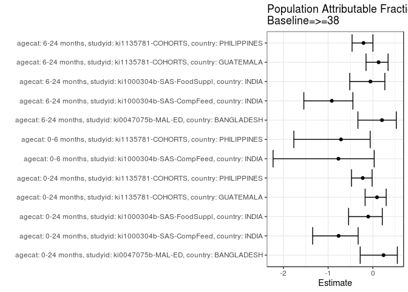

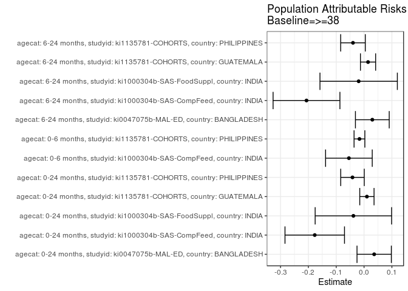

## Results Table

### Parameter: TSM

| agecat | studyid | country | intervention_level | baseline_level | estimate | ci_lower | ci_upper |
| --- | --- | --- | --- | --- | --- | --- | --- |
| 0-24 months | ki0047075b-MAL-ED | BANGLADESH | >=38 | NA | 0.1159420 | 0.0401494 | 0.1917347 |
| 0-24 months | ki0047075b-MAL-ED | BANGLADESH | <32 | NA | 0.2666667 | 0.1078978 | 0.4254355 |
| 0-24 months | ki0047075b-MAL-ED | BANGLADESH | [32-38) | NA | 0.1346154 | 0.0415386 | 0.2276921 |
| 0-24 months | ki1000304b-SAS-CompFeed | INDIA | >=38 | NA | 0.4081633 | 0.3007438 | 0.5155827 |
| 0-24 months | ki1000304b-SAS-CompFeed | INDIA | <32 | NA | 0.2191456 | 0.1806468 | 0.2576444 |
| 0-24 months | ki1000304b-SAS-CompFeed | INDIA | [32-38) | NA | 0.2639594 | 0.1913937 | 0.3365250 |
| 0-24 months | ki1000304b-SAS-FoodSuppl | INDIA | >=38 | NA | 0.4090909 | 0.2636414 | 0.5545404 |
| 0-24 months | ki1000304b-SAS-FoodSuppl | INDIA | <32 | NA | 0.3771626 | 0.3212164 | 0.4331089 |
| 0-24 months | ki1000304b-SAS-FoodSuppl | INDIA | [32-38) | NA | 0.3294118 | 0.2293758 | 0.4294478 |
| 0-24 months | ki1135781-COHORTS | GUATEMALA | >=38 | NA | 0.0994764 | 0.0694507 | 0.1295021 |
| 0-24 months | ki1135781-COHORTS | GUATEMALA | <32 | NA | 0.0998336 | 0.0758574 | 0.1238098 |
| 0-24 months | ki1135781-COHORTS | GUATEMALA | [32-38) | NA | 0.1423841 | 0.1029574 | 0.1818108 |
| 0-24 months | ki1135781-COHORTS | PHILIPPINES | >=38 | NA | 0.2256098 | 0.1803675 | 0.2708520 |
| 0-24 months | ki1135781-COHORTS | PHILIPPINES | <32 | NA | 0.1788814 | 0.1623845 | 0.1953783 |
| 0-24 months | ki1135781-COHORTS | PHILIPPINES | [32-38) | NA | 0.1787709 | 0.1463582 | 0.2111837 |
| 0-6 months | ki1000304b-SAS-CompFeed | INDIA | >=38 | NA | 0.1250000 | 0.0265956 | 0.2234044 |
| 0-6 months | ki1000304b-SAS-CompFeed | INDIA | <32 | NA | 0.0635930 | 0.0431567 | 0.0840293 |
| 0-6 months | ki1000304b-SAS-CompFeed | INDIA | [32-38) | NA | 0.1025641 | 0.0610899 | 0.1440383 |
| 0-6 months | ki1135781-COHORTS | PHILIPPINES | >=38 | NA | 0.0396341 | 0.0185169 | 0.0607514 |
| 0-6 months | ki1135781-COHORTS | PHILIPPINES | <32 | NA | 0.0192957 | 0.0133730 | 0.0252184 |
| 0-6 months | ki1135781-COHORTS | PHILIPPINES | [32-38) | NA | 0.0279330 | 0.0139936 | 0.0418723 |
| 6-24 months | ki0047075b-MAL-ED | BANGLADESH | >=38 | NA | 0.1159420 | 0.0401494 | 0.1917347 |
| 6-24 months | ki0047075b-MAL-ED | BANGLADESH | <32 | NA | 0.2333333 | 0.0814808 | 0.3851858 |
| 6-24 months | ki0047075b-MAL-ED | BANGLADESH | [32-38) | NA | 0.1346154 | 0.0415386 | 0.2276921 |
| 6-24 months | ki1000304b-SAS-CompFeed | INDIA | >=38 | NA | 0.4318182 | 0.3044703 | 0.5591660 |
| 6-24 months | ki1000304b-SAS-CompFeed | INDIA | <32 | NA | 0.2121471 | 0.1803638 | 0.2439305 |
| 6-24 months | ki1000304b-SAS-CompFeed | INDIA | [32-38) | NA | 0.2601156 | 0.1922645 | 0.3279668 |
| 6-24 months | ki1000304b-SAS-FoodSuppl | INDIA | >=38 | NA | 0.3809524 | 0.2339031 | 0.5280017 |
| 6-24 months | ki1000304b-SAS-FoodSuppl | INDIA | <32 | NA | 0.3655914 | 0.3090104 | 0.4221724 |
| 6-24 months | ki1000304b-SAS-FoodSuppl | INDIA | [32-38) | NA | 0.3375000 | 0.2337531 | 0.4412469 |
| 6-24 months | ki1135781-COHORTS | GUATEMALA | >=38 | NA | 0.0973451 | 0.0657767 | 0.1289136 |
| 6-24 months | ki1135781-COHORTS | GUATEMALA | <32 | NA | 0.1098901 | 0.0836455 | 0.1361347 |
| 6-24 months | ki1135781-COHORTS | GUATEMALA | [32-38) | NA | 0.1326165 | 0.0928024 | 0.1724306 |
| 6-24 months | ki1135781-COHORTS | PHILIPPINES | >=38 | NA | 0.2302632 | 0.1829290 | 0.2775973 |
| 6-24 months | ki1135781-COHORTS | PHILIPPINES | <32 | NA | 0.1857666 | 0.1683262 | 0.2032070 |
| 6-24 months | ki1135781-COHORTS | PHILIPPINES | [32-38) | NA | 0.1845238 | 0.1506515 | 0.2183961 |

### Parameter: E(Y)

| agecat | studyid | country | intervention_level | baseline_level | estimate | ci_lower | ci_upper |
| --- | --- | --- | --- | --- | --- | --- | --- |
| 0-24 months | ki0047075b-MAL-ED | BANGLADESH | NA | NA | 0.1523179 | 0.0948144 | 0.2098214 |
| 0-24 months | ki1000304b-SAS-CompFeed | INDIA | NA | NA | 0.2311258 | 0.1911027 | 0.2711489 |
| 0-24 months | ki1000304b-SAS-FoodSuppl | INDIA | NA | NA | 0.3708134 | 0.3244530 | 0.4171738 |
| 0-24 months | ki1135781-COHORTS | GUATEMALA | NA | NA | 0.1097276 | 0.0926320 | 0.1268233 |
| 0-24 months | ki1135781-COHORTS | PHILIPPINES | NA | NA | 0.1840762 | 0.1700627 | 0.1980897 |
| 0-6 months | ki1000304b-SAS-CompFeed | INDIA | NA | NA | 0.0706196 | 0.0480792 | 0.0931600 |
| 0-6 months | ki1135781-COHORTS | PHILIPPINES | NA | NA | 0.0231450 | 0.0177070 | 0.0285830 |
| 6-24 months | ki0047075b-MAL-ED | BANGLADESH | NA | NA | 0.1456954 | 0.0892366 | 0.2021542 |
| 6-24 months | ki1000304b-SAS-CompFeed | INDIA | NA | NA | 0.2251082 | 0.1905625 | 0.2596539 |
| 6-24 months | ki1000304b-SAS-FoodSuppl | INDIA | NA | NA | 0.3615960 | 0.3145115 | 0.4086805 |
| 6-24 months | ki1135781-COHORTS | GUATEMALA | NA | NA | 0.1116838 | 0.0935814 | 0.1297863 |
| 6-24 months | ki1135781-COHORTS | PHILIPPINES | NA | NA | 0.1905112 | 0.1757477 | 0.2052747 |

### Parameter: RR

| agecat | studyid | country | intervention_level | baseline_level | estimate | ci_lower | ci_upper |
| --- | --- | --- | --- | --- | --- | --- | --- |
| 0-24 months | ki0047075b-MAL-ED | BANGLADESH | >=38 | >=38 | 1.0000000 | 1.0000000 | 1.0000000 |
| 0-24 months | ki0047075b-MAL-ED | BANGLADESH | <32 | >=38 | 2.3000000 | 0.9499965 | 5.5684414 |
| 0-24 months | ki0047075b-MAL-ED | BANGLADESH | [32-38) | >=38 | 1.1610577 | 0.4483418 | 3.0067571 |
| 0-24 months | ki1000304b-SAS-CompFeed | INDIA | >=38 | >=38 | 1.0000000 | 1.0000000 | 1.0000000 |
| 0-24 months | ki1000304b-SAS-CompFeed | INDIA | <32 | >=38 | 0.5369066 | 0.3989653 | 0.7225409 |
| 0-24 months | ki1000304b-SAS-CompFeed | INDIA | [32-38) | >=38 | 0.6467005 | 0.4406031 | 0.9492025 |
| 0-24 months | ki1000304b-SAS-FoodSuppl | INDIA | >=38 | >=38 | 1.0000000 | 1.0000000 | 1.0000000 |
| 0-24 months | ki1000304b-SAS-FoodSuppl | INDIA | <32 | >=38 | 0.9219531 | 0.6271896 | 1.3552481 |
| 0-24 months | ki1000304b-SAS-FoodSuppl | INDIA | [32-38) | >=38 | 0.8052288 | 0.5044882 | 1.2852498 |
| 0-24 months | ki1135781-COHORTS | GUATEMALA | >=38 | >=38 | 1.0000000 | 1.0000000 | 1.0000000 |
| 0-24 months | ki1135781-COHORTS | GUATEMALA | <32 | >=38 | 1.0035905 | 0.6823994 | 1.4759595 |
| 0-24 months | ki1135781-COHORTS | GUATEMALA | [32-38) | >=38 | 1.4313349 | 0.9502749 | 2.1559233 |
| 0-24 months | ki1135781-COHORTS | PHILIPPINES | >=38 | >=38 | 1.0000000 | 1.0000000 | 1.0000000 |
| 0-24 months | ki1135781-COHORTS | PHILIPPINES | <32 | >=38 | 0.7928797 | 0.6358411 | 0.9887033 |
| 0-24 months | ki1135781-COHORTS | PHILIPPINES | [32-38) | >=38 | 0.7923902 | 0.6046858 | 1.0383610 |
| 0-6 months | ki1000304b-SAS-CompFeed | INDIA | >=38 | >=38 | 1.0000000 | 1.0000000 | 1.0000000 |
| 0-6 months | ki1000304b-SAS-CompFeed | INDIA | <32 | >=38 | 0.5087440 | 0.2651710 | 0.9760514 |
| 0-6 months | ki1000304b-SAS-CompFeed | INDIA | [32-38) | >=38 | 0.8205128 | 0.4199560 | 1.6031234 |
| 0-6 months | ki1135781-COHORTS | PHILIPPINES | >=38 | >=38 | 1.0000000 | 1.0000000 | 1.0000000 |
| 0-6 months | ki1135781-COHORTS | PHILIPPINES | <32 | >=38 | 0.4868455 | 0.2632360 | 0.9004034 |
| 0-6 months | ki1135781-COHORTS | PHILIPPINES | [32-38) | >=38 | 0.7047701 | 0.3396327 | 1.4624649 |
| 6-24 months | ki0047075b-MAL-ED | BANGLADESH | >=38 | >=38 | 1.0000000 | 1.0000000 | 1.0000000 |
| 6-24 months | ki0047075b-MAL-ED | BANGLADESH | <32 | >=38 | 2.0125000 | 0.8000739 | 5.0622279 |
| 6-24 months | ki0047075b-MAL-ED | BANGLADESH | [32-38) | >=38 | 1.1610577 | 0.4483418 | 3.0067571 |
| 6-24 months | ki1000304b-SAS-CompFeed | INDIA | >=38 | >=38 | 1.0000000 | 1.0000000 | 1.0000000 |
| 6-24 months | ki1000304b-SAS-CompFeed | INDIA | <32 | >=38 | 0.4912881 | 0.3641271 | 0.6628564 |
| 6-24 months | ki1000304b-SAS-CompFeed | INDIA | [32-38) | >=38 | 0.6023730 | 0.4240155 | 0.8557547 |
| 6-24 months | ki1000304b-SAS-FoodSuppl | INDIA | >=38 | >=38 | 1.0000000 | 1.0000000 | 1.0000000 |
| 6-24 months | ki1000304b-SAS-FoodSuppl | INDIA | <32 | >=38 | 0.9596774 | 0.6331595 | 1.4545793 |
| 6-24 months | ki1000304b-SAS-FoodSuppl | INDIA | [32-38) | >=38 | 0.8859375 | 0.5408793 | 1.4511282 |
| 6-24 months | ki1135781-COHORTS | GUATEMALA | >=38 | >=38 | 1.0000000 | 1.0000000 | 1.0000000 |
| 6-24 months | ki1135781-COHORTS | GUATEMALA | <32 | >=38 | 1.1288711 | 0.7546301 | 1.6887082 |
| 6-24 months | ki1135781-COHORTS | GUATEMALA | [32-38) | >=38 | 1.3623330 | 0.8757040 | 2.1193818 |
| 6-24 months | ki1135781-COHORTS | PHILIPPINES | >=38 | >=38 | 1.0000000 | 1.0000000 | 1.0000000 |
| 6-24 months | ki1135781-COHORTS | PHILIPPINES | <32 | >=38 | 0.8067579 | 0.6435722 | 1.0113213 |
| 6-24 months | ki1135781-COHORTS | PHILIPPINES | [32-38) | >=38 | 0.8013605 | 0.6083280 | 1.0556456 |

### Parameter: PAR

| agecat | studyid | country | intervention_level | baseline_level | estimate | ci_lower | ci_upper |
| --- | --- | --- | --- | --- | --- | --- | --- |
| 0-24 months | ki0047075b-MAL-ED | BANGLADESH | >=38 | NA | 0.0363759 | -0.0252782 | 0.0980299 |
| 0-24 months | ki1000304b-SAS-CompFeed | INDIA | >=38 | NA | -0.1770374 | -0.2839012 | -0.0701737 |
| 0-24 months | ki1000304b-SAS-FoodSuppl | INDIA | >=38 | NA | -0.0382775 | -0.1755766 | 0.0990216 |
| 0-24 months | ki1135781-COHORTS | GUATEMALA | >=38 | NA | 0.0102512 | -0.0153962 | 0.0358986 |
| 0-24 months | ki1135781-COHORTS | PHILIPPINES | >=38 | NA | -0.0415335 | -0.0837990 | 0.0007319 |
| 0-6 months | ki1000304b-SAS-CompFeed | INDIA | >=38 | NA | -0.0543804 | -0.1381804 | 0.0294196 |
| 0-6 months | ki1135781-COHORTS | PHILIPPINES | >=38 | NA | -0.0164891 | -0.0358784 | 0.0029001 |
| 6-24 months | ki0047075b-MAL-ED | BANGLADESH | >=38 | NA | 0.0297533 | -0.0309275 | 0.0904341 |
| 6-24 months | ki1000304b-SAS-CompFeed | INDIA | >=38 | NA | -0.2067100 | -0.3267393 | -0.0866806 |
| 6-24 months | ki1000304b-SAS-FoodSuppl | INDIA | >=38 | NA | -0.0193564 | -0.1583198 | 0.1196071 |
| 6-24 months | ki1135781-COHORTS | GUATEMALA | >=38 | NA | 0.0143387 | -0.0129338 | 0.0416112 |
| 6-24 months | ki1135781-COHORTS | PHILIPPINES | >=38 | NA | -0.0397519 | -0.0839953 | 0.0044914 |

### Parameter: PAF

| agecat | studyid | country | intervention_level | baseline_level | estimate | ci_lower | ci_upper |
| --- | --- | --- | --- | --- | --- | --- | --- |
| 0-24 months | ki0047075b-MAL-ED | BANGLADESH | >=38 | NA | 0.2388154 | -0.2830190 | 0.5484073 |
| 0-24 months | ki1000304b-SAS-CompFeed | INDIA | >=38 | NA | -0.7659786 | -1.3474312 | -0.3285503 |
| 0-24 months | ki1000304b-SAS-FoodSuppl | INDIA | >=38 | NA | -0.1032258 | -0.5432948 | 0.2113580 |
| 0-24 months | ki1135781-COHORTS | GUATEMALA | >=38 | NA | 0.0934239 | -0.1727541 | 0.2991880 |
| 0-24 months | ki1135781-COHORTS | PHILIPPINES | >=38 | NA | -0.2256323 | -0.4778097 | -0.0164871 |
| 0-6 months | ki1000304b-SAS-CompFeed | INDIA | >=38 | NA | -0.7700472 | -2.2322597 | 0.0306883 |
| 0-6 months | ki1135781-COHORTS | PHILIPPINES | >=38 | NA | -0.7124283 | -1.7678208 | -0.0594654 |
| 6-24 months | ki0047075b-MAL-ED | BANGLADESH | >=38 | NA | 0.2042161 | -0.3337776 | 0.5252042 |
| 6-24 months | ki1000304b-SAS-CompFeed | INDIA | >=38 | NA | -0.9182692 | -1.5436390 | -0.4466506 |
| 6-24 months | ki1000304b-SAS-FoodSuppl | INDIA | >=38 | NA | -0.0535304 | -0.5173076 | 0.2684896 |
| 6-24 months | ki1135781-COHORTS | GUATEMALA | >=38 | NA | 0.1283866 | -0.1525286 | 0.3408321 |
| 6-24 months | ki1135781-COHORTS | PHILIPPINES | >=38 | NA | -0.2086593 | -0.4644115 | 0.0024270 |